# RPiSM projekt nr 1 - rozkład gamma

Aleksandra Talaga, Urszula Zastawna, Karolina Węgrzyn

2023-12-28

## **Wstęp**

W naszym projekcie badamy rozkład gamma.  
Parametr kształtu k rozkładu gamma oznaczamy jako a i przyjmujemy trzy różne wartości (a = 0.1; 1; 10)  
Parametr skali 𝜃 rozkładu gamma oznaczamy jako b i przyjmujemy zawsze wartość b = 1  
Rozkład badamy w dwóch wariantach:  
Wariant 1: generujemy dane z rozkładu.  
Wariant 2: generujemy dane z rozkładu i podnosimy je do kwadratu.

## **Kod**

### Biblioteki

```r
library(moments)
library(dplyr)
library(ggplot2)
```

### Ustawienie ziarna

```r
set.seed(10)
```

Aby generowane przez nas liczby były takie same przy każdym uruchomieniu kodu, ustawiamy ziarno generatora.

### Główna funkcja

Funkcja ta jest odpowiedzialna za generowanie liczb z rozkładu gamma w odpowiednim wariancie, przyjmując odpowiednie parametry oraz za obliczanie statystyk (średniej, odchylenia standardowego, skośności i kurtozy) i przeprowadzenie testu Shapiro-Wilka. Wywołując tę funkcję z odpowiednimi parametrami w dalszej części projektu, otrzymamy wyniki, które będziemy analizować.

```r
funkcja <- function(N, k_values, a_values, b, wariant) {
  wyniki <- data.frame()
  ramki_danych_srednia <- data.frame()
  ramki_danych_odch <- data.frame()
  ramki_danych_skosnosc <- data.frame()
  ramki_danych_kurtoza <- data.frame()
  ramki_danych_shapiro <- data.frame()


  for (k in k_values) {
    for (a in a_values) {
      srednie_arytmetyczne <- numeric(N)

      for (i in 1:N) {
        # Wariant 1: Wylosowanie danych z rozkładu gamma
        # Wariant 2: Wylosowanie danych z rozkładu gamma i podniesienie ich do kwadratu
        dane <- switch(wariant,
                       {rgamma(k, shape = a, scale = b)},
                       {(rgamma(k, shape = a, scale = b))^2}
        )

        srednie_arytmetyczne[i] <- mean(dane)
      }

      srednia <- mean(srednie_arytmetyczne)
      odch_stand <- sd(srednie_arytmetyczne)
      skosnosc <- skewness(srednie_arytmetyczne)
      kurtoza <- kurtosis(srednie_arytmetyczne)

      # Test Shapiro-Wilka
      shapiro_test <- shapiro.test(srednie_arytmetyczne)
      reject_h0 <- ifelse(shapiro_test$p.value < 0.05, "tak", "nie")

      nowy_wiersz <- data.frame(
        k = k,
        a = a,
        b = b,
        srednie_arytmetyczne = srednie_arytmetyczne,
        srednia = srednia,
        odch_stand = odch_stand,
        skosnosc = skosnosc,
        kurtoza = kurtoza,
        odrzucenie_h0 = reject_h0,
        wariant = wariant
      )

      wyniki <- rbind(wyniki, nowy_wiersz)

      # Tworzenie ramki danych dla średniej
      nowy_wiersz_srednia <- data.frame(
        k = k,
        a = a,
        srednia = mean(srednie_arytmetyczne)
      )

      ramki_danych_srednia <- rbind(ramki_danych_srednia, nowy_wiersz_srednia)

      # Tworzenie ramki danych dla odchylenie standardowego
      nowy_wiersz_odch <- data.frame(
        k = k,
        a = a,
        odchylenie = sd(srednie_arytmetyczne)
      )

      ramki_danych_odch <- rbind(ramki_danych_odch, nowy_wiersz_odch)

      # Tworzenie ramki danych dla skosnosci
      nowy_wiersz_skosnosc <- data.frame(
        k = k,
        a = a,
        skosnosc = skewness(srednie_arytmetyczne)
      )

      ramki_danych_skosnosc <- rbind(ramki_danych_skosnosc, nowy_wiersz_skosnosc)

      # Tworzenie ramki danych dla kurtozy
      nowy_wiersz_kurtoza <- data.frame(
        k = k,
        a = a,
        kurtoza = kurtosis(srednie_arytmetyczne)
      )

      ramki_danych_kurtoza <- rbind(ramki_danych_kurtoza, nowy_wiersz_kurtoza)


      # Tworzenie ramki danych dla testu shapiro wilka
      nowy_wiersz_shapiro <- data.frame(
        k = k,
        a = a,
        shapiro_p_value = shapiro_test$p.value,
        odrzucenie_h0 = reject_h0
      )

      ramki_danych_shapiro <- rbind(ramki_danych_shapiro, nowy_wiersz_shapiro)

    }
  }


  cat("Zestawienie wyników:\n")
  for (a_val in unique(wyniki$a)) {
    cat("\nDla a =", a_val, ":\n")
    for (k_val in unique(wyniki$k)) {
      cat("  Dla k =", k_val, ":\n")
      for (wariant_val in unique(wyniki$wariant)) {
        subset_data <- wyniki[wyniki$a == a_val & wyniki$k == k_val & wyniki$wariant == wariant_val, ]
        cat("    Średnia arytmetyczna:", mean(subset_data$srednie_arytmetyczne), "\n")
        cat("    Odchylenie standardowe:", sd(subset_data$srednie_arytmetyczne), "\n")
        cat("    Skośność:", skewness(subset_data$srednie_arytmetyczne), "\n")
        cat("    Kurtoza:", kurtosis(subset_data$srednie_arytmetyczne), "\n")
        cat("    Średnie mają rozkład normalny:", any(subset_data$odrzucenie_h0 == "nie"), "\n")
      }
    }
  }

  # Zwracamy listę zawierającą 6 ramek danych
  return(list
         (wyniki = wyniki,
           ramki_danych_kurtoza = ramki_danych_kurtoza,
           ramki_danych_srednia = ramki_danych_srednia,
           ramki_danych_odch = ramki_danych_odch,
           ramki_danych_skosnosc = ramki_danych_skosnosc,
           ramki_danych_shapiro = ramki_danych_shapiro)
         )
}
```

### Funkcja tworząca wykresy pudełkowe

```r
generuj_wykresy_pudelkowe <- function(wyniki, k_values, a_values) {
  for (j in seq_along(a_values)) {
    a <- a_values[j]

    dane_do_wykresu <- wyniki[wyniki$a == a, ]

    p <- ggplot(dane_do_wykresu, aes(x = as.factor(k), y = srednie_arytmetyczne, fill = as.factor(k))) +
      geom_boxplot(notch = TRUE, varwidth = TRUE) +
      labs(title = paste("Wykres pudełkowy dla a =", a),
           x = "k", y = "Średnie arytmetyczne", fill = "Wartości k") +
      scale_fill_manual(values = rainbow(length(k_values))) +
      theme_minimal()
    print(p)
  }
}
```

### Funkcja tworząca krzywe gęstości

```r
generuj_wykres_gestosci <- function(wyniki, k_values, a_values) {

   for (j in seq_along(a_values)) {
    a <- a_values[j]
    dane_do_wykresu <- wyniki[wyniki$a == a, ]

    p <- ggplot() +
      geom_density(data = dane_do_wykresu, aes(x = srednie_arytmetyczne, color = as.factor(k)), linewidth=1.0) +
      labs(title = paste("Krzywe gęstości dla a =", a),
           x = "Średnie arytmetyczne", y = "Gęstość") +
      theme_minimal() +
      guides(color = guide_legend(title = "Wartości k"))
    print(p)
  }
}
```

### Ustawienie odpowiednich wartości

Ustawiamy odpowiednie wartości parametrów zgodnie z treścią projektu.  
N - liczba powtórzeń  
k_values - ile liczb losujemy z rozkładu gamma  
a_values - parametry kształtu  
b - parametr skali

```r
N <- 300
k_values <- c(5, 10, 20, 30, 50, 100, 200, 500, 1000)
a_values <- c(0.1, 1, 10)
b <- 1
```

## **Przeprowadzenie symulacji**

### Wariant 1

#### **Teoretyczne charakterystyki rozkładu**

**Wartość oczekiwana:**
$$k\theta$$
czyli w naszym przypadku:
$$ab$$

**Odchylenie standardowe:** (pierwiastek z wariancji):
$$\sqrt{k\theta^2}=\sqrt k\theta$$
czyli w naszym przypadku:
$$\sqrt
ab$$

**Skośność:**
$$\frac{2}{\sqrt k}$$
czyli w naszym przypadku:
$$\frac{2}{\sqrt a}$$

**Kurtoza:**
$$\frac{6}{k}$$
czyli w naszym przypadku:
$$\frac{6}{a}$$

Obliczamy teoretyczne statystyki rozkładu dla odpowiednich a, korzystając ze wzorów.

```r
statystyki1 <- data.frame()
for (a in a_values) {
  statystyki1 <- rbind(statystyki1, c(a, b, a*b, sqrt(a)*b, 2/sqrt(a), 6/a))
}
colnames (statystyki1) <- c("a", "b", "wartość oczekiwana", "odchylenie standardowe", "wsp.skośności", "kurtoza")
statystyki1
```

| a | b | wartość oczekiwana | odchylenie standardowe | wsp.skośności | kurtoza |
| --- | --- | --- | --- | --- | --- |
| 0.1 | 1 | 0.1 | 0.3162278 | 6.3245553 | 60.0 |
| 1.0 | 1 | 1.0 | 1.0000000 | 2.0000000 | 6.0 |
| 10.0 | 1 | 10.0 | 3.1622777 | 0.6324555 | 0.6 |

Wartość oczekiwana jest równa wartości parametru kształtu a, przy b=1. Odchylenie standardowe wzrasta wraz ze wzrostem wartości a. Natomiast współczynnik skośności i kurtoza maleją wraz ze wzrostem a, co oznacza, że wykres staje się coraz bardziej symetryczny i coraz bardziej spłaszczony

**Krzywe gęstości**

Generujemy 1000 punktów z przedziału między 0 a 20. Funkcja dgamma służy do obliczania wartości funkcji gęstości prawdopodobieństwa w określonym punkcie. Przedstawiamy to na wykresie.

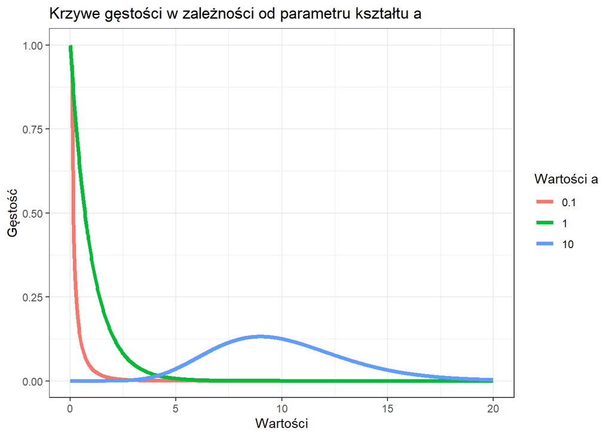

```r
df1 <- expand.grid(x = seq(0, 20, length = 1000), a = a_values) %>%
  mutate(y = dgamma(x, shape = a, scale = b))

df1 %>%
  ggplot(aes(x = x, y = y, color = factor(a))) +
  geom_line(linewidth = 1.5) +
  labs(x = "Wartości", y = "Gęstość", title = "Krzywe gęstości w zależności od parametru kształtu a") +
  ylim(0, 1) +
  theme_bw() +
  guides(color = guide_legend(title = "Wartości a"))
```

Im większa wartość parametru a (parametru kształtu), tym rozkład jest bardziej ‘spłaszczony’, czyli wartości są słabiej skoncentrowane wokół średniej, co potwierdzają wyznaczone wartości kurtozy. Dla a = 0.1 oraz a = 1 występuje także silna asymetria prawostronna, wydłużone jest prawe ramię rozkładu, co również ma swoje uzasadnienie w wyznaczonych powyżej współczynnikach asymetrii.

#### **Generowanie wartości**

```r
test_wariant_1 <- funkcja(N, k_values, a_values, b, wariant = 1)
```

```
## Zestawienie wyników:
##
## Dla a = 0.1 :
##   Dla k = 5 :
##     Średnia arytmetyczna: 0.09569026
##     Odchylenie standardowe: 0.1309633
##     Skośność: 2.25614
##     Kurtoza: 8.764981
##     Średnie mają rozkład normalny: FALSE
##   Dla k = 10 :
##     Średnia arytmetyczna: 0.09479573
##     Odchylenie standardowe: 0.09717987
##     Skośność: 2.051232
##     Kurtoza: 8.352071
##     Średnie mają rozkład normalny: FALSE
##   Dla k = 20 :
##     Średnia arytmetyczna: 0.1059042
##     Odchylenie standardowe: 0.07642034
##     Skośność: 1.294084
##     Kurtoza: 4.654191
##     Średnie mają rozkład normalny: FALSE
##   Dla k = 30 :
##     Średnia arytmetyczna: 0.09530318
##     Odchylenie standardowe: 0.05727163
##     Skośność: 1.277195
##     Kurtoza: 5.272698
##     Średnie mają rozkład normalny: FALSE
##   Dla k = 50 :
##     Średnia arytmetyczna: 0.09688654
##     Odchylenie standardowe: 0.0438559
##     Skośność: 0.9437174
##     Kurtoza: 4.33087
##     Średnie mają rozkład normalny: FALSE
##   Dla k = 100 :
##     Średnia arytmetyczna: 0.09970534
##     Odchylenie standardowe: 0.02901951
##     Skośność: 0.5049267
##     Kurtoza: 3.053844
##     Średnie mają rozkład normalny: FALSE
##   Dla k = 200 :
```

[output cut: 114 more lines]

```
##     Skośność: 0.1819071
##     Kurtoza: 2.908396
##     Średnie mają rozkład normalny: TRUE
##   Dla k = 500 :
##     Średnia arytmetyczna: 10.00283
##     Odchylenie standardowe: 0.1358571
##     Skośność: 0.02945643
##     Kurtoza: 3.290547
##     Średnie mają rozkład normalny: TRUE
##   Dla k = 1000 :
##     Średnia arytmetyczna: 10.00009
##     Odchylenie standardowe: 0.103072
##     Skośność: 0.1884395
##     Kurtoza: 3.332343
##     Średnie mają rozkład normalny: TRUE
```

Funkcja zwraca nam wszystkie obliczone parametry dla wariantu 1. Aby jednak wyciągnąć wnioski i móc przeanalizować dokładniej wyniki, podzielimy je według przyjmowanego parametru a i przeanalizujemy osobno dla średniej, odchylenia standardowego, skośności, kurtozy oraz testu Shapiro-Wilka.

```r
# Wyniki
wyniki_wariant1 <- test_wariant_1$wyniki

# Średnia
srednia_podzielona_wariant1 <- split(test_wariant_1$ramki_danych_srednia, test_wariant_1$ramki_danych_srednia$a)

# Odchylenie standardowe
odch_podzielona_wariant1 <- split(test_wariant_1$ramki_danych_odch, test_wariant_1$ramki_danych_odch$a)

# Skośność
skosnosc_podzielona_wariant1 <- split(test_wariant_1$ramki_danych_skosnosc, test_wariant_1$ramki_danych_skosnosc$a)

# Kurtoza
kurtoza_podzielona_wariant1 <- split(test_wariant_1$ramki_danych_kurtoza, test_wariant_1$ramki_danych_kurtoza$a)

#Test Shapiro-Wilka
shapiro_podzielone_wariant1 <- split(test_wariant_1$ramki_danych_shapiro, test_wariant_1$ramki_danych_shapiro$a)
```

#### **Średnia arytmetyczna**

Dla a = 0.1

```r
print(srednia_podzielona_wariant1$"0.1")
```

```
##       k   a    srednia
## 1     5 0.1 0.09569026
## 4    10 0.1 0.09479573
## 7    20 0.1 0.10590415
## 10   30 0.1 0.09530318
## 13   50 0.1 0.09688654
## 16  100 0.1 0.09970534
## 19  200 0.1 0.10021491
## 22  500 0.1 0.10013397
## 25 1000 0.1 0.09906689
```

Dla a = 1

```r
print(srednia_podzielona_wariant1$"1")
```

```
##       k a   srednia
## 2     5 1 1.0203634
## 5    10 1 1.0039640
## 8    20 1 0.9722315
## 11   30 1 1.0057728
## 14   50 1 1.0165044
## 17  100 1 1.0057836
## 20  200 1 0.9983427
## 23  500 1 1.0038192
## 26 1000 1 1.0003229
```

Dla a = 10

```r
print(srednia_podzielona_wariant1$"10")
```

```
##       k  a   srednia
## 3     5 10  9.934172
## 6    10 10 10.028129
## 9    20 10  9.926941
## 12   30 10  9.962908
## 15   50 10 10.037212
## 18  100 10 10.010225
## 21  200 10 10.002716
## 24  500 10 10.002830
## 27 1000 10 10.000087
```

Widać, że na średnią arytmetyczną nie ma wpływu, ile liczb losowaliśmy z danego rozkładu. Średnia jest bardzo podobna do siebie dla wszystkich k. Widać, że średnia przyjmuje wartości bardzo zbliżone do parametru kształtu rozkładu gamma - a.  
**Wnioski:** Liczba losowanych danych nie ma wpływu na średnią arytmetyczną. Parametr kształtu bezpośrednio przekłada się na średnią arytmetyczną.

#### **Odchylenie standardowe**

Dla a = 0.1

```r
print(odch_podzielona_wariant1$"0.1")
```

```
##       k   a  odchylenie
## 1     5 0.1 0.130963314
## 4    10 0.1 0.097179867
## 7    20 0.1 0.076420338
## 10   30 0.1 0.057271628
## 13   50 0.1 0.043855900
## 16  100 0.1 0.029019506
## 19  200 0.1 0.022041059
## 22  500 0.1 0.013687823
## 25 1000 0.1 0.009622051
```

Dla a = 1

```r
print(odch_podzielona_wariant1$"1")
```

```
##       k a odchylenie
## 2     5 1 0.47389435
## 5    10 1 0.33356372
## 8    20 1 0.23852788
## 11   30 1 0.17932689
## 14   50 1 0.13253204
## 17  100 1 0.09335605
## 20  200 1 0.07462534
## 23  500 1 0.04474969
## 26 1000 1 0.03276626
```

Dla a = 10

```r
print(odch_podzielona_wariant1$"10")
```

```
##       k  a odchylenie
## 3     5 10  1.4705836
## 6    10 10  0.9418951
## 9    20 10  0.6795914
## 12   30 10  0.5689940
## 15   50 10  0.4359344
## 18  100 10  0.3031366
## 21  200 10  0.2378265
## 24  500 10  0.1358571
## 27 1000 10  0.1030720
```

Wraz ze wzrostem liczby danych losowanych z rozkładu zmniejsza się odchylenie standardowe. Widać to w każdej z trzech sytuacji dla każdego a. Dodatkowo widać, że czym większe a, tym większe jest odchylenie standardowe. Najmniejsze odchylenie jest dla a = 0.1, a największe dla a = 10.  
**Wnioski:** Liczba losowanych danych ma wpływ na odchylenie standardowe (im więcej danych tym odchylenie jest mniejsze). Wraz ze wzrostem parametru kształtu wzrasta również odchylenie.

#### **Skośność**

Dla a = 0.1

```r
print(skosnosc_podzielona_wariant1$"0.1")
```

```
##       k   a   skosnosc
## 1     5 0.1 2.25613961
## 4    10 0.1 2.05123184
## 7    20 0.1 1.29408421
## 10   30 0.1 1.27719469
## 13   50 0.1 0.94371739
## 16  100 0.1 0.50492668
## 19  200 0.1 0.22864432
## 22  500 0.1 0.39258599
## 25 1000 0.1 0.04127551
```

Dla a = 0.1 wraz ze wzrostem liczby losowanych danych zmniejsza się współczynnik asymetrii. Dla małych k współczynnik jest duży (wskazuje na silną asymetrie prawostronną), natomiast gdy k rośnie, współczynnik coraz bardziej przybliża się do 0 czyli do symetrycznego rozkładu.

Dla a = 1

```r
print(skosnosc_podzielona_wariant1$"1")
```

```
##       k a    skosnosc
## 2     5 1  0.84274815
## 5    10 1  0.69173887
## 8    20 1  0.46237548
## 11   30 1  0.29624625
## 14   50 1  0.26978788
## 17  100 1  0.02890678
## 20  200 1  0.14722519
## 23  500 1  0.23114596
## 26 1000 1 -0.02640564
```

Dla a = 1 trudniej jest wyciągnąć jednoznaczne wnioski. Do pewnego momentu (k = 100) wraz ze wzrostem k maleje współczynnik asymetrii. Dla k = 100 rozkład jest bliski symetrii (współczynnik bliski zeru). Jednak dalej ze wzrostem k współczynnik znów rośnie, a dla k = 1000 przyjmuje wartość ujemną, co wskazuje na asymetrie lewostronną. Jednak dla k = 1000 ujemna wartość współczynnika jest wciąż bardzo bliska zeru. Ze wszystkich k najbardziej symetryczny rozkład jest dla k = 100 i k = 1000

Dla a = 10

```r
print(skosnosc_podzielona_wariant1$"10")
```

```
##       k  a    skosnosc
## 3     5 10  0.07852641
## 6    10 10  0.07690254
## 9    20 10  0.27377023
## 12   30 10  0.01668039
## 15   50 10 -0.04274931
## 18  100 10 -0.03691077
## 21  200 10  0.18190711
## 24  500 10  0.02945643
## 27 1000 10  0.18843949
```

Przy a = 10 dla każdego k współczynnik jest dość mały (największą wartość przyjmuje w przybliżeniu około 0.27). Dla k = 50 i k = 100 współczynnik jest ujemny, jednakże także wciąż bliski zeru. W tej sytuacji dla każdego k rozkład jest bliski symetrii.  
**Wnioski:** Czym większy jest parametr kształtu a, tym mniejszy wpływ na asymetrię rozkładu ma liczba wylosowanych danych. Widać, że dla a = 0.1 liczba wylosowanych danych ma bardzo duży wpływ na symetrię rozkładu i dla małych k rozkład jest niesymetryczny z silną asymetrią prawostronną. Jednakże dla większych a, parametr k nie ma już takego dużego wpływu na asymetrię. Dla a = 10 niemal dla każdego k rozkład jest symetryczny.

#### **Kurtoza**

**Kurtozę interpretuje się tylko dla rozkładów symetrycznych!**

Dla a = 0.1

```r
print(kurtoza_podzielona_wariant1$"0.1")
```

```
##       k   a  kurtoza
## 1     5 0.1 8.764981
## 4    10 0.1 8.352071
## 7    20 0.1 4.654191
## 10   30 0.1 5.272698
## 13   50 0.1 4.330870
## 16  100 0.1 3.053844
## 19  200 0.1 3.076264
## 22  500 0.1 3.464619
## 25 1000 0.1 3.350899
```

Dla a = 0.1 tylko w przypadku k=1000 możemy stwierdzić, że rozkład jest symetryczny. Kurtoza wyniosła wówczas ok. 3.35, czyli rozkład jest lekko leptokurtyczny - wartości charakteryzują się dużym skupieniem wokół średniej.

Dla a = 1

```r
print(kurtoza_podzielona_wariant1$"1")
```

```
##       k a  kurtoza
## 2     5 1 3.717619
## 5    10 1 3.502888
## 8    20 1 3.945115
## 11   30 1 3.402955
## 14   50 1 3.400990
## 17  100 1 2.971976
## 20  200 1 2.568549
## 23  500 1 2.650213
## 26 1000 1 3.218222
```

Dla a = 1 rozkład jest w miarę symetryczny dla k=100 oraz k=1000. Przy k=100 kurtoza wyniosła 2.97, czyli można uznać, że rozkład jest mezokurtyczny, a przy k=1000 wyniosła 3.22, czyli jest to rozkład lekko leptokurtyczny.

Dla a = 10

```r
print(kurtoza_podzielona_wariant1$"10")
```

```
##       k  a  kurtoza
## 3     5 10 2.629308
## 6    10 10 2.848708
## 9    20 10 3.024837
## 12   30 10 2.695342
## 15   50 10 2.853481
## 18  100 10 2.706049
## 21  200 10 2.908396
## 24  500 10 3.290547
## 27 1000 10 3.332343
```

Dla a = 10 rozkład jest bliski symetrii niemal dla każdego k. Wszystkie wartości kurtozy oscylują wokół wartości 3, czyli można powiedzieć, że rozkłady są mezokurtyczne - mają podobną koncentrację do rozkładu normalnego.

#### **Test normalności**

Hipoteza h0: Dane pochodzą z rozkładu normalnego.  
Hipoteza h1: Dane nie pochodzą z rozkładu normalnego.  
Zakładamy poziom istotności α = 0.05.

Dla a = 0.1

```r
print(shapiro_podzielone_wariant1$"0.1")
```

```
##       k   a shapiro_p_value odrzucenie_h0
## 1     5 0.1    3.836374e-22           tak
## 4    10 0.1    4.574233e-19           tak
## 7    20 0.1    1.189262e-13           tak
## 10   30 0.1    3.709037e-12           tak
## 13   50 0.1    2.628814e-08           tak
## 16  100 0.1    1.835927e-04           tak
## 19  200 0.1    3.494352e-01           nie
## 22  500 0.1    8.475069e-03           tak
## 25 1000 0.1    7.612539e-01           nie
```

Dla a = 0.1 jedynie przy k = 200 i k = 1000 nie odrzucamy hipotezy zerowej, czyli przyjmujemy, że dane pochodzą z rozkładu normalnego. W innych przypadkach odrzucamy tą hipotezę na poziomie istotności α = 0.05.

Dla a = 1

```r
print(shapiro_podzielone_wariant1$"1")
```

```
##       k a shapiro_p_value odrzucenie_h0
## 2     5 1    4.831793e-08           tak
## 5    10 1    9.384753e-06           tak
## 8    20 1    1.149157e-03           tak
## 11   30 1    4.005193e-02           tak
## 14   50 1    2.547919e-01           nie
## 17  100 1    4.936162e-01           nie
## 20  200 1    7.385674e-02           nie
## 23  500 1    1.669975e-02           tak
## 26 1000 1    4.050337e-01           nie
```

Dla a = 1 w przypadku k = 50, 100, 200, 1000 możemy przyjąć hipotezę, że dane pochodzą z rozkładu normalnego za prawdziwą na poziomie istotności α = 0.05.

Dla a = 10

```r
print(shapiro_podzielone_wariant1$"10")
```

```
##       k  a shapiro_p_value odrzucenie_h0
## 3     5 10       0.5845763           nie
## 6    10 10       0.4123923           nie
## 9    20 10       0.1922078           nie
## 12   30 10       0.8409798           nie
## 15   50 10       0.3897933           nie
## 18  100 10       0.4791850           nie
## 21  200 10       0.5968340           nie
## 24  500 10       0.8940553           nie
## 27 1000 10       0.3300826           nie
```

Dla a = 10 niezależnie od k nie odrzucamy hipotezy o tym, że rozkład, z którego pochodzą dane jest normalny. Czyli zakładamy, że te dane pochodzą z rozkładu normalnego na przyjętym poziomie istotności.  
**Wnioski:** Wraz ze wzrostem a zwiększa się szansa na to, że dane będą miały rozkład normalny.

#### **Wykresy pudełkowe**

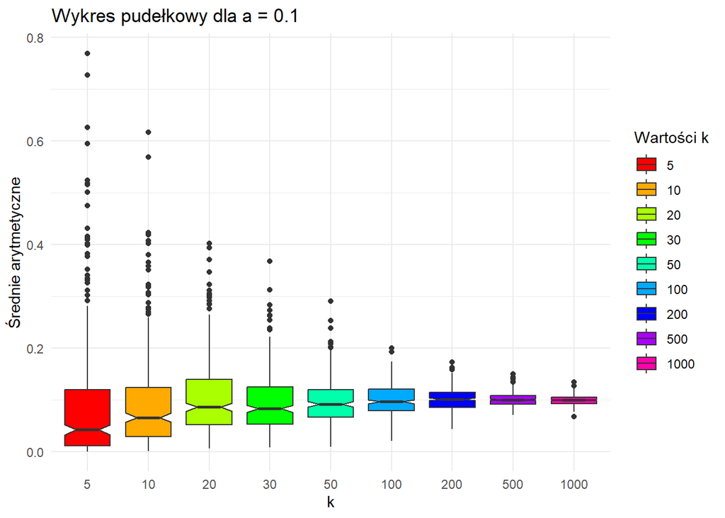

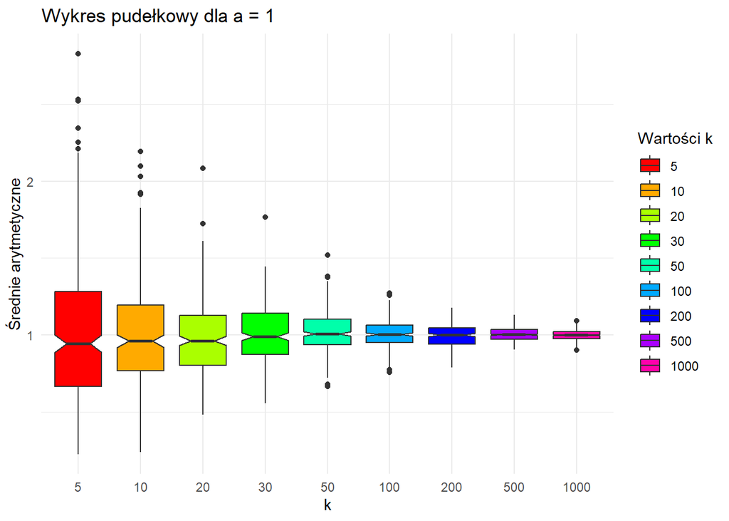

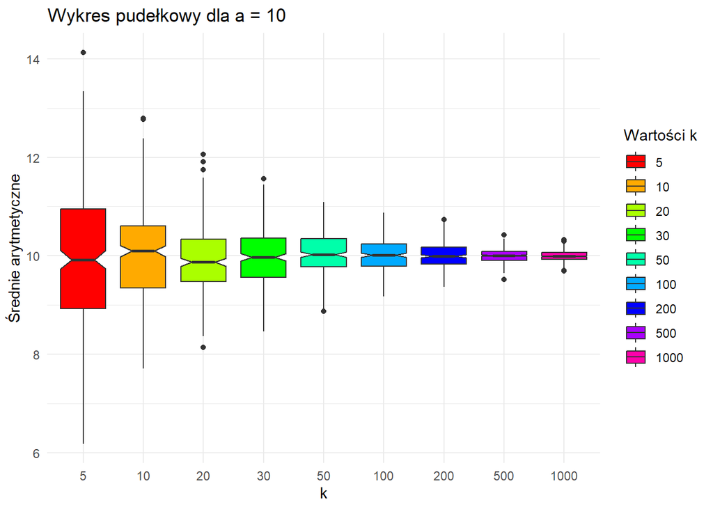

```r
generuj_wykresy_pudelkowe(wyniki_wariant1, k_values, a_values)
```

**Wnioski:** Wraz ze wzrostem liczby danych maleje wielkość pudełka, a także liczba wartości odstających. W przypadku a = 0.1 dla małej liczby danych, część pudełka nad kreską, oznaczającą medianę jest znacznie większa niż część pod kreską, a także jest dużo wartości odstających na górze, co informuje o prawostronnej asymetrii. Wraz ze wzrostem liczby danych asymetria ta maleje. Warto zauważyć, że wraz ze wzrostem parametru a zwiększa się rozstęp ćwiartkowy (różnica między trzecim a pierwszym kwartylem), który zawiera w sobie 50% obserwacji. Można z tego wnioskować, że wraz ze wzrostem a wzrasta również odchylenie standardowe (co potwierdzają wyżej policzone statystyki).

#### **Krzywe gęstości**

Przedstawiamy krzywe na osobnych wykresach dla każdej wartości parametru a z podziałem kolorystycznym na wartość k (liczbę danych), jednak z dostosowaną skalą do wartości na każdym wykresie, aby lepiej odczytać, jak liczba danych wpływa na kształt krzywej.

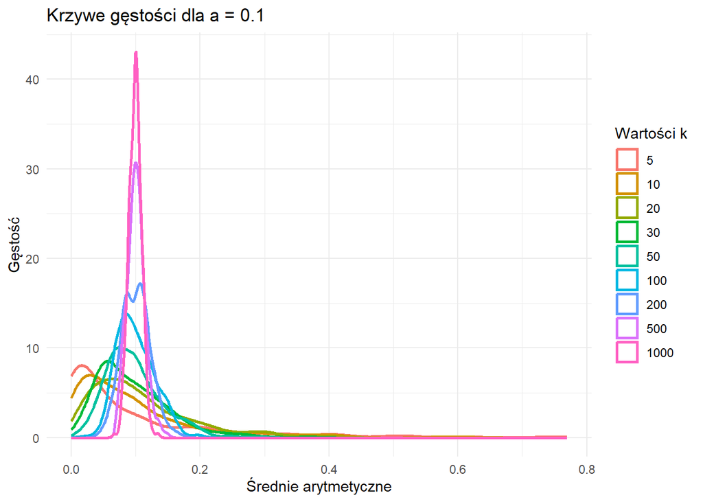

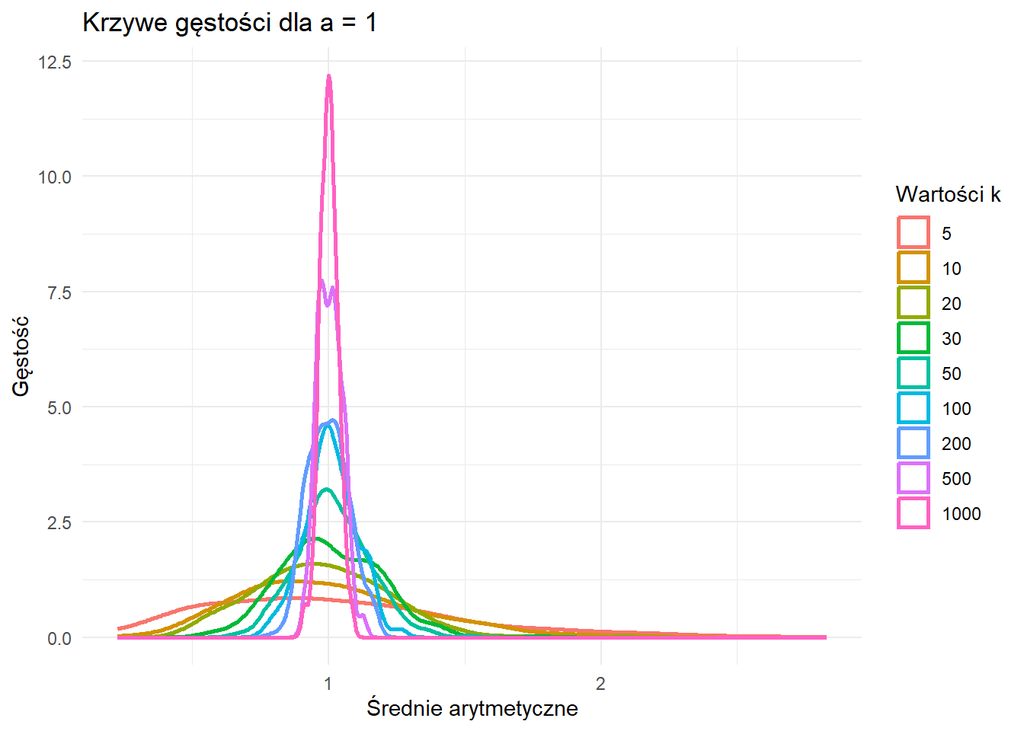

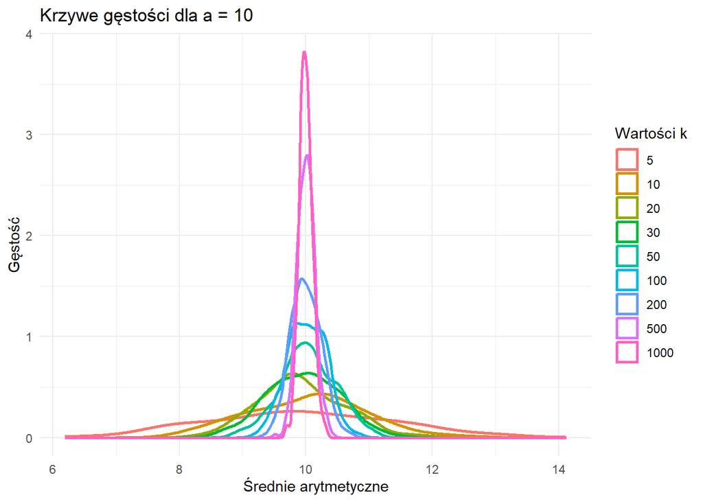

```r
generuj_wykres_gestosci(wyniki_wariant1, k_values, a_values)
```

**Wnioski:** Dla a = 0.1 wartości krzywej gęstości sięgają nawet ponad 40, podczas gdy dla a = 10 są mniejsze od 4.  
Dla każdej wartości parametru a, wraz ze wzrostem liczby danych (k) rozkład jest bardziej wysmuklony, wartości są silniej skoncentrowane wokół średnej.  
Dla a = 0.1 szczególnie widać także, że wraz ze wzrostem liczby danych, rozkład staje się bardziej symetryczny, co potwierdza wcześniejsze wnioski dotyczące skośności.

### Wariant 2

#### **Teoretyczne charakterystyki rozkładu**

Losujemy 10000 danych z rozkładu gamma, aby na ich podstawie przedstawić charakterystykę rozkładu. Obliczamy odpowiednie statystyki dla różnych a.

```r
statystyki2 <- data.frame()
for (a in a_values) {
  dane <- (rgamma(10000, shape=a, scale=b))^2
  statystyki2 <- rbind(statystyki2, c(a, b, mean(dane), sd(dane), skewness(dane), kurtosis(dane)))
}
colnames (statystyki2) <- c("a", "b", "wartość oczekiwana", "odchylenie standardowe", "wsp.skośności", "kurtoza")
statystyki2
```

| a | b | wartość oczekiwana | odchylenie standardowe | wsp.skośności | kurtoza |
| --- | --- | --- | --- | --- | --- |
| 0.1 | 1 | 0.1035384 | 0.8272727 | 24.293850 | 859.432170 |
| 1.0 | 1 | 1.9600176 | 4.4313056 | 7.028810 | 90.351148 |
| 10.0 | 1 | 110.0413323 | 70.8772646 | 1.710076 | 8.719658 |

Wartość oczekiwana wzrasta wraz ze wzrostem parametru a. Podobnie jak w przypadku wariantu pierwszego odchylenie standardowe również wzrasta. Natomiast współczynnik skośności i kurtoza maleją wraz ze wzrostem a, co oznacza, że wykres staje się coraz bardziej symetryczny i coraz bardziej spłaszczony. Warto zauważyć, że wartości odchylenia, skośności i kurtozy dla odpowiednich a są o wiele wyższe niż w wariancie pierwszym.

#### **Generowanie wartości**

```r
test_wariant_2 <- funkcja(N, k_values, a_values, b, wariant = 2)
```

```
## Zestawienie wyników:
##
## Dla a = 0.1 :
##   Dla k = 5 :
##     Średnia arytmetyczna: 0.1411175
##     Odchylenie standardowe: 0.5202172
##     Skośność: 10.62227
##     Kurtoza: 143.7563
##     Średnie mają rozkład normalny: FALSE
##   Dla k = 10 :
##     Średnia arytmetyczna: 0.1084443
##     Odchylenie standardowe: 0.2646829
##     Skośność: 5.332934
##     Kurtoza: 39.32143
##     Średnie mają rozkład normalny: FALSE
##   Dla k = 20 :
##     Średnia arytmetyczna: 0.1196011
##     Odchylenie standardowe: 0.1919889
##     Skośność: 3.628199
##     Kurtoza: 19.32491
##     Średnie mają rozkład normalny: FALSE
##   Dla k = 30 :
##     Średnia arytmetyczna: 0.1276472
##     Odchylenie standardowe: 0.1743993
##     Skośność: 3.187289
##     Kurtoza: 16.94048
##     Średnie mają rozkład normalny: FALSE
##   Dla k = 50 :
##     Średnia arytmetyczna: 0.1163201
##     Odchylenie standardowe: 0.1170665
##     Skośność: 2.097208
##     Kurtoza: 7.881265
##     Średnie mają rozkład normalny: FALSE
##   Dla k = 100 :
##     Średnia arytmetyczna: 0.1112619
##     Odchylenie standardowe: 0.08077313
##     Skośność: 1.774045
##     Kurtoza: 7.507229
##     Średnie mają rozkład normalny: FALSE
##   Dla k = 200 :
```

[output cut: 114 more lines]

```
##     Skośność: -0.03622636
##     Kurtoza: 2.865769
##     Średnie mają rozkład normalny: TRUE
##   Dla k = 500 :
##     Średnia arytmetyczna: 109.7532
##     Odchylenie standardowe: 2.950068
##     Skośność: -0.08622678
##     Kurtoza: 2.88985
##     Średnie mają rozkład normalny: TRUE
##   Dla k = 1000 :
##     Średnia arytmetyczna: 110.1565
##     Odchylenie standardowe: 2.310541
##     Skośność: -0.1435441
##     Kurtoza: 2.601981
##     Średnie mają rozkład normalny: TRUE
```

```r
# Wyniki
wyniki_wariant2 <- test_wariant_2$wyniki

# Średnia
srednia_podzielona_wariant2 <- split(test_wariant_2$ramki_danych_srednia, test_wariant_2$ramki_danych_srednia$a)

# Odchylenie standardowe
odch_podzielona_wariant2 <- split(test_wariant_2$ramki_danych_odch, test_wariant_2$ramki_danych_odch$a)

# Skośność
skosnosc_podzielona_wariant2 <- split(test_wariant_2$ramki_danych_skosnosc, test_wariant_2$ramki_danych_skosnosc$a)

# Kurtoza
kurtoza_podzielona_wariant2 <- split(test_wariant_2$ramki_danych_kurtoza, test_wariant_2$ramki_danych_kurtoza$a)

# Test Shapiro-Wilka
shapiro_podzielone_wariant2 <- split(test_wariant_2$ramki_danych_shapiro, test_wariant_2$ramki_danych_shapiro$a)
```

#### **Średnia arytmetyczna**

Dla a = 0.1

```r
print(srednia_podzielona_wariant2$"0.1")
```

```
##       k   a   srednia
## 1     5 0.1 0.1411175
## 4    10 0.1 0.1084443
## 7    20 0.1 0.1196011
## 10   30 0.1 0.1276472
## 13   50 0.1 0.1163201
## 16  100 0.1 0.1112619
## 19  200 0.1 0.1077394
## 22  500 0.1 0.1097703
## 25 1000 0.1 0.1106267
```

Dla a = 1

```r
print(srednia_podzielona_wariant2$"1")
```

```
##       k a  srednia
## 2     5 1 1.968571
## 5    10 1 2.101519
## 8    20 1 1.956833
## 11   30 1 2.033548
## 14   50 1 2.003390
## 17  100 1 2.017131
## 20  200 1 1.974815
## 23  500 1 1.975101
## 26 1000 1 1.984287
```

Dla a = 10

```r
print(srednia_podzielona_wariant2$"10")
```

```
##       k  a  srednia
## 3     5 10 109.8130
## 6    10 10 109.0124
## 9    20 10 109.6236
## 12   30 10 110.8516
## 15   50 10 110.6691
## 18  100 10 109.9984
## 21  200 10 109.7786
## 24  500 10 109.7532
## 27 1000 10 110.1565
```

Podobnie jak w wariancie 1, widać, że k nie ma wpływu na średnią arytmetyczną. We wszystkich przypadkach dla każdej wartości przyjmowanej przez k średnia ma podobną wartość.

**Wnioski:** Liczba losowanych danych nie ma wpływu na średnią, natomiast parametr kształtu a wpływa na średnią. Dla a = 0.1 średnia również wynosi około 0.1. Natomiast dla a = 1 średnia wynosi w przybliżeniu 2, a dla a = 10 średnia wynosi w przybliżeniu 110.

#### **Odchylenie standardowe**

Dla a = 0.1

```r
print(odch_podzielona_wariant2$"0.1")
```

```
##       k   a odchylenie
## 1     5 0.1 0.52021717
## 4    10 0.1 0.26468290
## 7    20 0.1 0.19198895
## 10   30 0.1 0.17439932
## 13   50 0.1 0.11706654
## 16  100 0.1 0.08077313
## 19  200 0.1 0.05769763
## 22  500 0.1 0.03575793
## 25 1000 0.1 0.02727376
```

Dla a = 1

```r
print(odch_podzielona_wariant2$"1")
```

```
##       k a odchylenie
## 2     5 1  1.9516437
## 5    10 1  1.5834450
## 8    20 1  1.0091067
## 11   30 1  0.8048556
## 14   50 1  0.6123603
## 17  100 1  0.4465359
## 20  200 1  0.3356698
## 23  500 1  0.2139583
## 26 1000 1  0.1428297
```

Dla a = 10

```r
print(odch_podzielona_wariant2$"10")
```

```
##       k  a odchylenie
## 3     5 10  30.803007
## 6    10 10  20.573262
## 9    20 10  15.578121
## 12   30 10  13.066443
## 15   50 10   9.489379
## 18  100 10   7.341223
## 21  200 10   4.902700
## 24  500 10   2.950068
## 27 1000 10   2.310541
```

Podobnie jak w wariancie 1 widać, że wraz ze wzrostem k maleje odchylenie standardowe. Jednak wraz ze zwiększaniem parametru a odchylenie jest coraz większe.  
**Wnioski:** Liczba losowanych danych ma wpływ na odchylenie standardowe (czym więcej danych tym odchylenie jest mniejsze). Wraz ze wzrostem parametru kształtu wzrasta również odchylenie.

#### **Skośność**

Dla a = 0.1

```r
print(skosnosc_podzielona_wariant2$"0.1")
```

```
##       k   a   skosnosc
## 1     5 0.1 10.6222738
## 4    10 0.1  5.3329341
## 7    20 0.1  3.6281988
## 10   30 0.1  3.1872894
## 13   50 0.1  2.0972082
## 16  100 0.1  1.7740447
## 19  200 0.1  1.8158383
## 22  500 0.1  0.8219193
## 25 1000 0.1  1.2999067
```

Dla a = 0.1 analogicznie jak w pierwszym wariancie, uogólniając, wraz ze wzrostem liczby losowanych danych zmniejsza się współczynnik asymetrii, za wyjątkiem k=1000. Dla małych k współczynnik jest duży (wskazuje na silną asymetrie prawostronną), natomiast gdy k rośnie, współczynnik coraz bardziej przybliża się do 0 czyli do symetrycznego rozkładu. Warto zauważyć, że w tym wariancie asymetria dla małych k jest dużo silniejsza niż w wariancie pierwszym.

Dla a = 1

```r
print(skosnosc_podzielona_wariant2$"1")
```

```
##       k a  skosnosc
## 2     5 1 2.4580714
## 5    10 1 2.1567762
## 8    20 1 1.3004452
## 11   30 1 0.9692437
## 14   50 1 1.4167233
## 17  100 1 0.5841052
## 20  200 1 0.4084033
## 23  500 1 0.5107287
## 26 1000 1 0.4815166
```

Dla a = 1 do k=200, za wyjątkiem k=50, wraz ze wzrostem k zmniejsza się współczynnik asymetrii i wykres z silnej asymetrii prawostronnej staje się coraz bardziej symetryczny. Dla dalszych k współczynnik przyjmuje podobne wartości: w okolicach wartości 0.5.

Dla a = 10

```r
print(skosnosc_podzielona_wariant2$"10")
```

```
##       k  a    skosnosc
## 3     5 10  0.67578264
## 6    10 10  0.62887777
## 9    20 10  0.28309136
## 12   30 10  0.28379463
## 15   50 10  0.07194900
## 18  100 10  0.26624264
## 21  200 10 -0.03622636
## 24  500 10 -0.08622678
## 27 1000 10 -0.14354412
```

#### **Kurtoza**

**Kurtozę interpretuje się tylko dla rozkładów symetrycznych!**

Dla a = 0.1

```r
print(kurtoza_podzielona_wariant2$"0.1")
```

```
##       k   a    kurtoza
## 1     5 0.1 143.756339
## 4    10 0.1  39.321425
## 7    20 0.1  19.324913
## 10   30 0.1  16.940481
## 13   50 0.1   7.881265
## 16  100 0.1   7.507229
## 19  200 0.1   9.297904
## 22  500 0.1   3.649950
## 25 1000 0.1   8.314394
```

Dla a = 0.1 nie ma takiego k, dla którego współczynnik skośności byłby na tyle mały, że moglibyśmy uznać rozkład za symetryczny. Zatem nie interpretujemy żadnej kurtozy.

Dla a = 1

```r
print(kurtoza_podzielona_wariant2$"1")
```

```
##       k a   kurtoza
## 2     5 1 12.238680
## 5    10 1  9.443170
## 8    20 1  4.818184
## 11   30 1  4.324162
## 14   50 1  8.531796
## 17  100 1  3.286841
## 20  200 1  3.283764
## 23  500 1  3.572167
## 26 1000 1  5.043161
```

Dla a = 1, podobnie jak powyżej, nie ma takiego k, dla którego współczynnik skośności byłby na tyle mały, że moglibyśmy uznać rozkład za symetryczny. Zatem nie interpretujemy żadnej kurtozy.

Dla a = 10

```r
print(kurtoza_podzielona_wariant2$"10")
```

```
##       k  a  kurtoza
## 3     5 10 3.564994
## 6    10 10 5.021592
## 9    20 10 3.138670
## 12   30 10 3.389938
## 15   50 10 3.215399
## 18  100 10 3.122024
## 21  200 10 2.865769
## 24  500 10 2.889850
## 27 1000 10 2.601981
```

Dla a = 10 można uznać rozkład za symetryczny dla k=50, k=200, k=500 oraz k=1000. Kurtoza przyjmuje odpowiednio wartości: 3.22, 2.87, 2.89 i 2.6, zatem dla k=50 wnioskujemy, że rozkład jest lekko leptokurtyczny, a dla k=200, k=500 i k=1000 jest lekko platokurtyczny.

#### **Test normalności**

Hipoteza h0: Dane pochodzą z rozkładu normalnego.  
Hipoteza h1: Dane nie pochodzą z rozkładu normalnego.  
Zakładamy poziom istotności α = 0.05.

Dla a = 0.1

```r
print(shapiro_podzielone_wariant2$"0.1")
```

```
##       k   a shapiro_p_value odrzucenie_h0
## 1     5 0.1    5.621065e-33           tak
## 4    10 0.1    6.890213e-30           tak
## 7    20 0.1    4.001439e-26           tak
## 10   30 0.1    2.276414e-24           tak
## 13   50 0.1    3.363878e-20           tak
## 16  100 0.1    6.702681e-16           tak
## 19  200 0.1    1.001544e-14           tak
## 22  500 0.1    5.976077e-08           tak
## 25 1000 0.1    4.341448e-10           tak
```

Dla a = 0.1 odrzucamy hipotezę zerową w każdym przypadku, czyli dla żadnego k nie możemy uznać na poziomie istotności α = 0.05, że dane pochodzą z rozkładu normalnego.

Dla a = 1

```r
print(shapiro_podzielone_wariant2$"1")
```

```
##       k a shapiro_p_value odrzucenie_h0
## 2     5 1    2.669880e-20           tak
## 5    10 1    2.418959e-18           tak
## 8    20 1    4.978584e-13           tak
## 11   30 1    6.179935e-09           tak
## 14   50 1    5.260254e-11           tak
## 17  100 1    4.789252e-05           tak
## 20  200 1    6.273535e-03           tak
## 23  500 1    2.447865e-03           tak
## 26 1000 1    6.498359e-05           tak
```

Dla a = 10

```r
print(shapiro_podzielone_wariant2$"10")
```

```
##       k  a shapiro_p_value odrzucenie_h0
## 3     5 10    1.216935e-05           tak
## 6    10 10    2.686506e-05           tak
## 9    20 10    1.814257e-01           nie
## 12   30 10    4.783210e-02           tak
## 15   50 10    6.105530e-01           nie
## 18  100 10    2.339312e-01           nie
## 21  200 10    9.203953e-01           nie
## 24  500 10    9.461413e-01           nie
## 27 1000 10    2.288368e-01           nie
```

#### **Wykresy pudełkowe**

```r
generuj_wykresy_pudelkowe(wyniki_wariant2, k_values, a_values)
```

```
## Notch went outside hinges
## ℹ Do you want `notch = FALSE`?
```

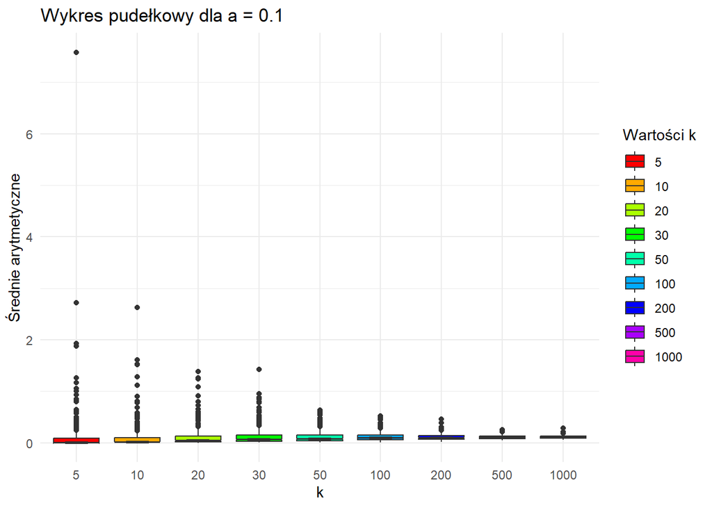

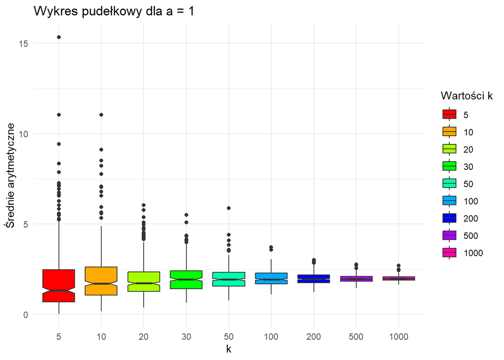

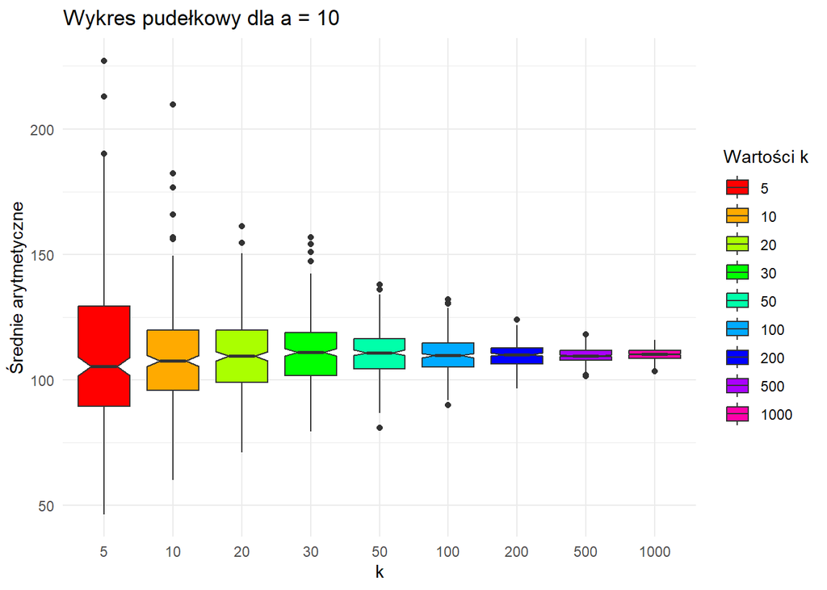

#### **Krzywe gęstości**

Przedstawiamy krzywe na osobnych wykresach dla każdej wartości parametru a z podziałem kolorystycznym na wartość k (liczbę danych), jednak z dostosowaną skalą do wartości na każdym wykresie, aby lepiej odczytać, jak liczba danych wpływa na kształt krzywej.

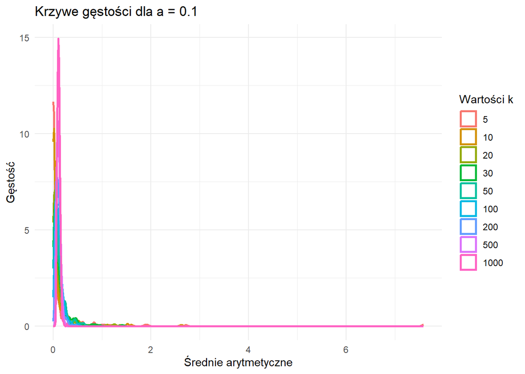

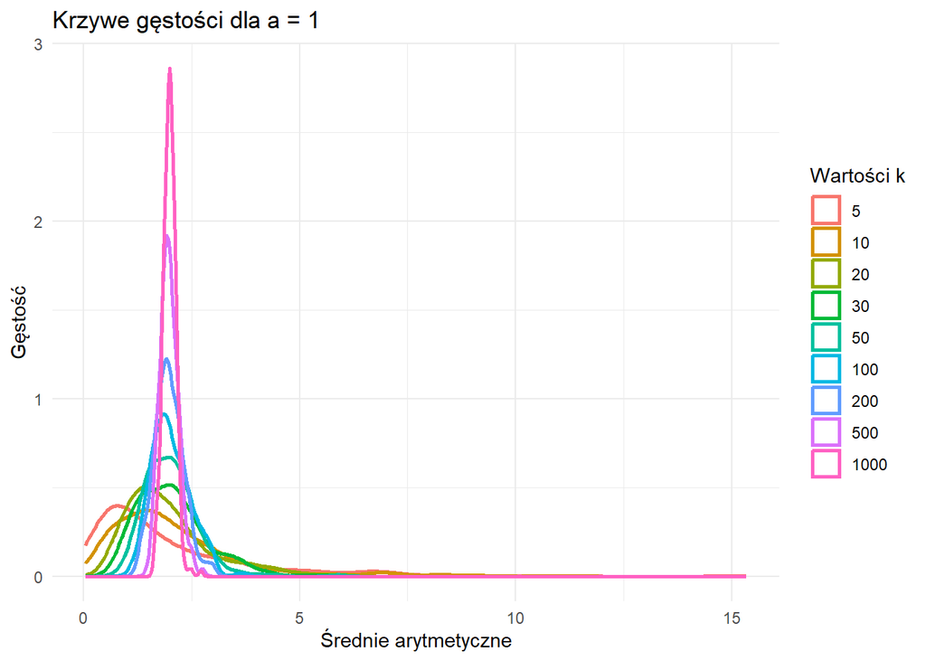

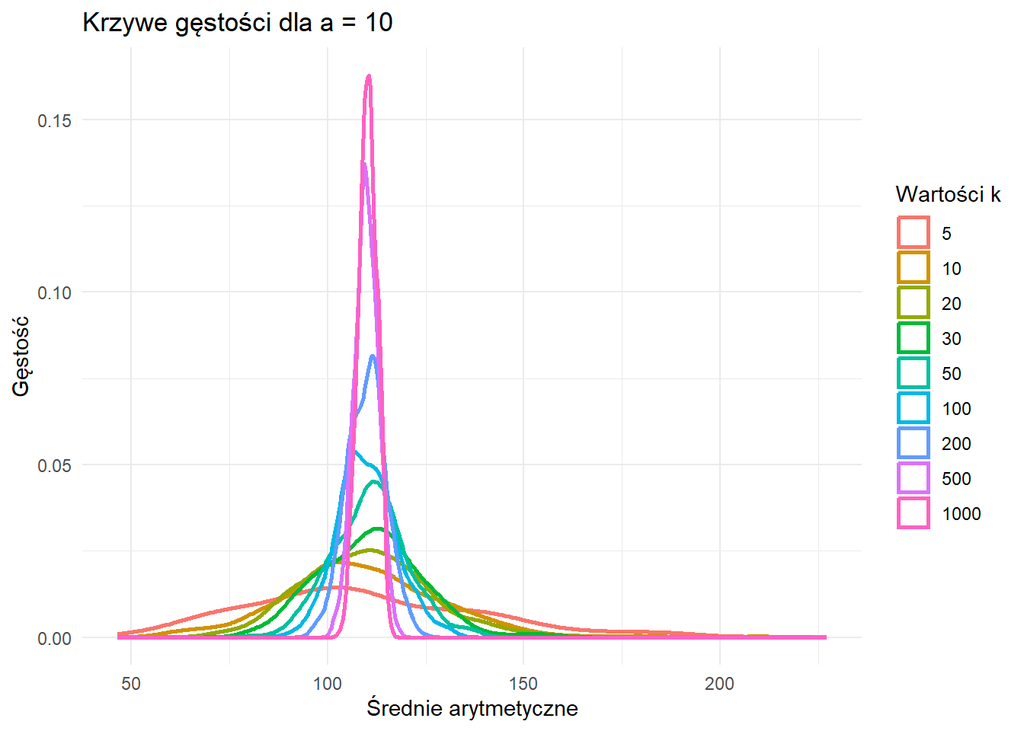

```r
generuj_wykres_gestosci(wyniki_wariant2, k_values, a_values)
```

**Wnioski:** Dla a = 0.1 wartości funkcji gęstości sięgają wartości ponad 15, podczas gdy dla a = 10 są mniejsze nawet od 0.2.  
Także dla każdej wartości parametru a, wraz ze wzrostem liczby danych (k) rozkład jest bardziej wysmuklony, wartości są silniej skoncentrowane wokół średnej.  
Dla a = 0.1 szczególnie widać także, że wraz ze wzrostem liczby danych, rozkład staje się bardziej symetryczny, co potwierdza wcześniejsze wnioski.